# Executive summary

480440172 | 490175477 | 480561916 | 480550367 | 470500790

The University of Sydney | DATA2002 Group M13-07

```r
data<-read_csv("https://raw.githubusercontent.com/DATA2002/data/master/boston.csv",na="NA")
data<-as.data.frame(data)

glimpse(data)
```

```
## Observations: 506
## Variables: 14
## $ CRIM    <dbl> 0.00632, 0.02731, 0.02729, 0.03237, 0.06905, 0.02985, ...
## $ ZN      <dbl> 18.0, 0.0, 0.0, 0.0, 0.0, 0.0, 12.5, 12.5, 12.5, 12.5,...
## $ INDUS   <dbl> 2.31, 7.07, 7.07, 2.18, 2.18, 2.18, 7.87, 7.87, 7.87, ...
## $ CHAS    <dbl> 0, 0, 0, 0, 0, 0, 0, 0, 0, 0, 0, 0, 0, 0, 0, 0, 0, 0, ...
## $ NOX     <dbl> 0.538, 0.469, 0.469, 0.458, 0.458, 0.458, 0.524, 0.524...
## $ RM      <dbl> 6.575, 6.421, 7.185, 6.998, 7.147, 6.430, 6.012, 6.172...
## $ AGE     <dbl> 65.2, 78.9, 61.1, 45.8, 54.2, 58.7, 66.6, 96.1, 100.0,...
## $ DIS     <dbl> 4.0900, 4.9671, 4.9671, 6.0622, 6.0622, 6.0622, 5.5605...
## $ RAD     <dbl> 1, 2, 2, 3, 3, 3, 5, 5, 5, 5, 5, 5, 5, 4, 4, 4, 4, 4, ...
## $ TAX     <dbl> 296, 242, 242, 222, 222, 222, 311, 311, 311, 311, 311,...
## $ PTRATIO <dbl> 15.3, 17.8, 17.8, 18.7, 18.7, 18.7, 15.2, 15.2, 15.2, ...
## $ B       <dbl> 396.90, 396.90, 392.83, 394.63, 396.90, 394.12, 395.60...
## $ LSTAT   <dbl> 4.98, 9.14, 4.03, 2.94, 5.33, 5.21, 12.43, 19.15, 29.9...
## $ MEDV    <dbl> 24.0, 21.6, 34.7, 33.4, 36.2, 28.7, 22.9, 27.1, 16.5, ...
```

## 0.2 second slide

**Data description**

#data set -Collected by the U.S. census concerning housing in Boston, Massachusetts.

-Contains 506 cases and was originally published in 1978.

#introduction -The aim for our report is to determine which factors significantly affect the housing prices.

-In this report we consider two factors that is the per capita crime rate by town and Nitric oxides concentration (PP10M).

#Abstract

-Data set we were assigned was originally titled “Hedonic prices and the demand for clean air”.

-This suggests that the prices of houses would be higher in areas with clean air so nitric oxide concentrations will be considered.

## 0.3 third slide

# 1 data set

This dataset has 14 variables;

1. CRIM: the per capita crime rate by town.
2. ZN: the proportion of residential land zoned for lots over 25,000 sq.ft.
3. INDUS: the proportion of non-retail business acres per town
4. CHAS: Charles River dummy variable( 1 if tract bounds river; 0 otherwise)
5. NOX: Nitric oxides concentration (PP10M)
6. RM: Average number of rooms per dwelling
7. AGE: Proportion of owner-occupied units built prior to 1940
8. DIS: Weighted distances to five Boston employment centres
9. RAD: Index of accessibility of radial highways
10. TAX: Full value property tax rate per $10,000
11. PTRATIO: Pupil- teacher ratio by town
12. B: 1000(Bk - 0.63)^2 where Bk is the proportion of blacks by town
13. LSTAT: % lower status of the population
14. MEDV: Medium value of owner-occupied homes in $1000’s.

## 1.1 fourth slide

**Analysis**

```r
library(GGally)
glimpse(data)  # glimpse the structure of the boston data
```

```
## Observations: 506
## Variables: 14
## $ CRIM    <dbl> 0.00632, 0.02731, 0.02729, 0.03237, 0.06905, 0.02985, ...
## $ ZN      <dbl> 18.0, 0.0, 0.0, 0.0, 0.0, 0.0, 12.5, 12.5, 12.5, 12.5,...
## $ INDUS   <dbl> 2.31, 7.07, 7.07, 2.18, 2.18, 2.18, 7.87, 7.87, 7.87, ...
## $ CHAS    <dbl> 0, 0, 0, 0, 0, 0, 0, 0, 0, 0, 0, 0, 0, 0, 0, 0, 0, 0, ...
## $ NOX     <dbl> 0.538, 0.469, 0.469, 0.458, 0.458, 0.458, 0.524, 0.524...
## $ RM      <dbl> 6.575, 6.421, 7.185, 6.998, 7.147, 6.430, 6.012, 6.172...
## $ AGE     <dbl> 65.2, 78.9, 61.1, 45.8, 54.2, 58.7, 66.6, 96.1, 100.0,...
## $ DIS     <dbl> 4.0900, 4.9671, 4.9671, 6.0622, 6.0622, 6.0622, 5.5605...
## $ RAD     <dbl> 1, 2, 2, 3, 3, 3, 5, 5, 5, 5, 5, 5, 5, 4, 4, 4, 4, 4, ...
## $ TAX     <dbl> 296, 242, 242, 222, 222, 222, 311, 311, 311, 311, 311,...
## $ PTRATIO <dbl> 15.3, 17.8, 17.8, 18.7, 18.7, 18.7, 15.2, 15.2, 15.2, ...
## $ B       <dbl> 396.90, 396.90, 392.83, 394.63, 396.90, 394.12, 395.60...
## $ LSTAT   <dbl> 4.98, 9.14, 4.03, 2.94, 5.33, 5.21, 12.43, 19.15, 29.9...
## $ MEDV    <dbl> 24.0, 21.6, 34.7, 33.4, 36.2, 28.7, 22.9, 27.1, 16.5, ...
```

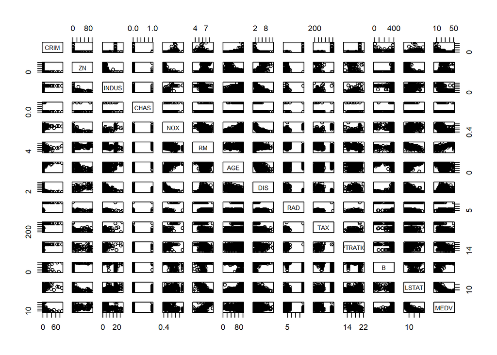

```r
pairs(data)  # traditional pairs plot
```

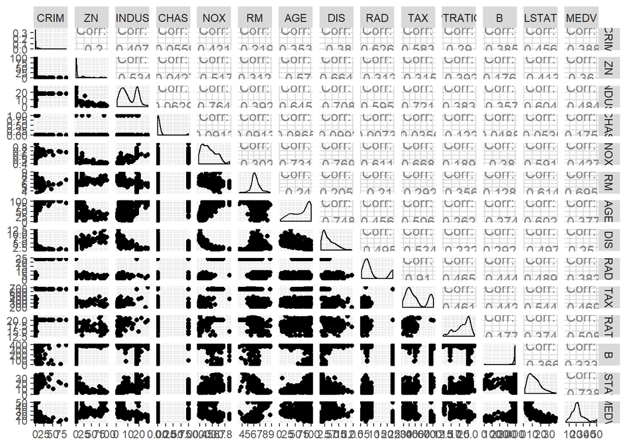

```r
GGally::ggpairs(data)  # ggplotified pairs plot
```

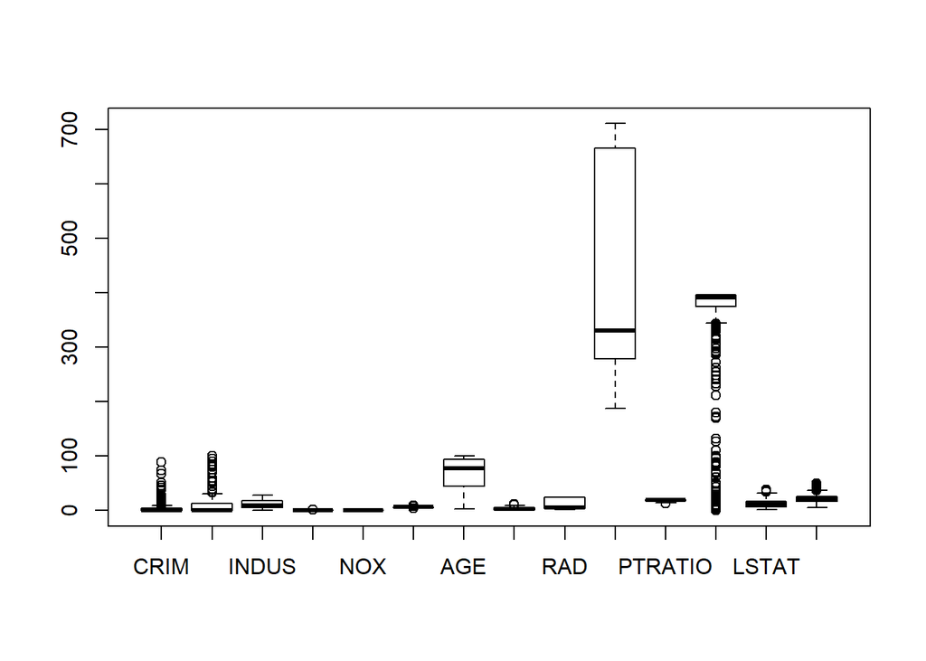

```r
boxplot(data)  # always a good idea to check for gross outliers
```